# Rで学ぶ計量経済学と機械学習 6 計量経済学２：操作変数法

This version: 2026-10-28

Author

安藤道人（立教大学） 三田匡能 (株式会社 GA technologies)

# 1 本講義の目的

- 操作変数法の実施方法を学ぶ。

# 2 パッケージの読み込み

今回の分析で使うパッケージを読み込む。

```r
pacman::p_load(tidyverse,
               modelsummary,
               skimr,
               ivreg,
               estimatr)
```

# 3 データの用意

前回と同じく、架空のデータを生成して分析を行う。

前回は個人の所得$Y$と学歴$X$・能力$A$との関係についての架空データを次のように生成した（ただし$\varepsilon$は誤差項）。

$$Y = 200 + 10A + 500X + \varepsilon$$

- サンプルサイズは10,000人
- 能力は0から100まで均等に分布する
- 能力が1上がると所得は10万円上昇する
- 能力が80 以上の約 2,000人中から約 1,000人がランダムに選ばれて大卒となる。
- 大卒だと所得が500万円上昇する
- 切片は200万円（能力=0、非大卒の平均給与）

[interactive chart not shown]

今回は、前回のデータに新たな変数を加える。**「能力に関係なく、30％の確率でランダムに選ばれた人が学費を免除され、入学を許可される」**という制度があるとし、さらに、**「学費免除に選ばれた人は、50%の確率で大学を卒業できる」**（ただし能力が80以上の条件で選ばれて大卒となった人はこの法則の対象外）とする。

[interactive chart not shown]

データ生成過程は、以下のように設定できる。（難しく感じる人は、コピペでかまわない）

前回は、`filter()`と`slice_sample()`で大卒の人を抽出し、`anti_join()`と`bind_rows()`で結合するという方法でデータを生成した。今回は、二項分布の乱数を発生させる`rbinom()`を用いて、`mutate()`の中で変数を1つずつ作っていく。

```r
# 乱数の種を固定（同じ種からは常に同じ乱数が生成される。10101を他の数値に変えると異なる乱数となる。）
set.seed(10101)

# n:サンプルサイズ
n <- 10000

# rbinom(n, 1, p): 確率pで1、確率1-pで0となる乱数をn個生成
# if_else(条件, 条件を満たすときの値, 満たさないときの値)
df <- tibble(ID = 1:n,
             ability = runif(n, min = 0, max = 100)) |>   # 能力は0から100まで均等に分布
  mutate(
    # 能力が80以上の人は、50%の確率で大卒になる（前回と同じ設定）
    university = if_else(ability >= 80, rbinom(n, 1, 0.5), 0),
    # 能力に関係なく、30%の確率で学費免除になる
    exemption = rbinom(n, 1, 0.3),
    # まだ大卒でない学費免除者は、50%の確率で大卒になる
    university = if_else(university == 0 & exemption == 1, rbinom(n, 1, 0.5), university),
    # DGPに基づいて所得を生成（誤差項は平均=0、標準偏差=50）
    income = 200 + 10*ability + 500*university + rnorm(n, mean = 0, sd = 50)
  )

# 最初の6行
head(df)
```

```
# A tibble: 6 × 5
     ID ability university exemption income
  <int>   <dbl>      <dbl>     <int>  <dbl>
1     1    19.0          0         0   434.
2     2    91.1          0         1  1089.
3     3    22.8          0         0   447.
4     4    82.5          1         0  1484.
5     5    91.6          0         0  1124.
6     6    50.5          0         1   684.
```

生成したデータの記述統計を、第3回で学んだ`skimr::skim()`で表示し、どのくらいが学費免除および大卒になったかチェックしてみる（0か1をとるダミー変数`exemption`と`university`の平均値`mean`は、それぞれ学費免除になった人と大卒の人の割合を表す）。

```r
skimr::skim(df)
```

Data summary

| Name | df |
| --- | --- |
| Number of rows | 10000 |
| Number of columns | 5 |
| _______________________ |  |
| Column type frequency: |  |
| numeric | 5 |
| ________________________ |  |
| Group variables | None |

**Variable type: numeric**

| skim_variable | n_missing | complete_rate | mean | sd | p0 | p25 | p50 | p75 | p100 | hist |
| --- | --- | --- | --- | --- | --- | --- | --- | --- | --- | --- |
| ID | 0 | 1 | 5000.50 | 2886.90 | 1.0 | 2500.75 | 5000.50 | 7500.25 | 10000.00 | ▇▇▇▇▇ |
| ability | 0 | 1 | 50.03 | 29.02 | 0.0 | 25.02 | 50.12 | 75.26 | 100.00 | ▇▇▇▇▇ |
| university | 0 | 1 | 0.24 | 0.42 | 0.0 | 0.00 | 0.00 | 0.00 | 1.00 | ▇▁▁▁▂ |
| exemption | 0 | 1 | 0.30 | 0.46 | 0.0 | 0.00 | 0.00 | 1.00 | 1.00 | ▇▁▁▁▃ |
| income | 0 | 1 | 818.29 | 406.51 | 110.7 | 494.46 | 770.64 | 1041.76 | 1830.47 | ▆▇▇▂▃ |

こうして生成したデータの所得と能力・学歴の関係をプロットすると次のようになる。前回と異なり、`ability`が80を下回っても、学費免除によって大学を卒業し、所得が上昇している人々がいることが分かる。

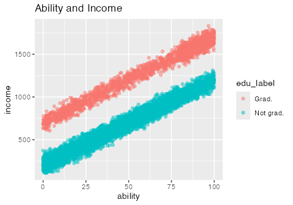

```r
# 大卒か否かのラベルをデータフレームに加える
df <- df |> mutate(edu_label =
                      case_when(university == 1 ~ "Grad.",
                                university == 0 ~ "Not grad."))

# 散布図を描く with 大卒ラベル
ggplot(df, aes(x = ability, y = income, color = edu_label)) +
  geom_point(alpha = 0.5) +
  labs(title = "Ability and Income")
```

以下では、「**学歴（大卒になること）が所得をどれだけ上昇させるのか**」を推定することを目的として分析していく。

# 4 操作変数法の概要

効果を測りたい処置変数（学歴$X$）を通じてのみアウトカム変数（所得$Y$)に影響を与える変数のことを**操作変数（instrumental variable）**という。そのような変数が存在することは多くないが、今回の場合は学費免除ダミー$Z$を操作変数として用いることができる。

前回、回帰分析などで学歴の効果を推定しようとした際には、交絡要因である能力がデータとして得られないという想定の下では 学歴の効果が過大に推定される問題が起こることを述べた。**操作変数法（instrumental variable method、IV method）**は操作変数から得られる情報を活用することで、そのような状況においてもよりよい推定を行う方法である。

## 4.1 操作変数法の求め方

ベーシックな操作変数推定値は、以下の２種類のやり方によって求めることができる（両者の推定値は一致する）。

1. **二段階最小二乗法(TSLS)**：学歴$X$の変動のうち、学費免除$Z$の変動による変動分$\hat{X}$を推計し（第一段階）、$\hat{X}$→所得$Y$の因果効果を推定する（第二段階）。
2. **誘導型推定値を第一段階推定値で割る**：学費免除→学歴の因果効果（第一段階）、学費免除→所得の因果効果（誘導型）はそれぞれ回帰分析で推定できるので、この二つの推定値を利用して、以下のように推定する

$$学歴X\to 所得Y \text{の因果効果} = \frac{学費免除Z \to 所得Y\text{の因果効果}}{学費免除Z \to 学歴X\text{の因果効果}}$$

実際には、第一段階の推定結果を開示しつつも、操作変数推定値およびその標準誤差は二段階最小二乗法(TSLS)によって求めることがほとんどである。

なお二段階最小二乗法を用いる場合は、手動で二段階の推定を行うのではなく、下記で提示するパッケージなどを使うこと。自ら$\hat{X}$を推定し、それを$Y$に回帰して推定値と標準誤差を得ると、誤った標準誤差を算出することになる。

# 5 Rで実践

## 5.1 欠落変数を無視した回帰分析

まず、欠落変数（能力$A$)を無視して、$Y$を$X$に回帰してみる。単純な単回帰に加えて、学費免除$Z$をコントロール変数に加えた重回帰分析も行ってみる。

回帰分析結果は以下のようになる。

```r
reg_biased1 <- lm(formula = income ~ university,
                  data = df)
reg_biased2 <- lm(formula = income ~ university + exemption,
                  data = df)

modelsummary(list(reg_biased1, reg_biased2),
             stars = TRUE,
             gof_omit = "AIC|BIC|Log.Lik|RMSE")
```

|  | (1) | (2) |
| --- | --- | --- |
| (Intercept) | 656.331*** | 675.631*** |
|  | (3.240) | (3.426) |
| university | 686.845*** | 745.569*** |
|  | (6.673) | (7.567) |
| exemption |  | -110.899*** |
|  |  | (7.016) |
| Num.Obs. | 10000 | 10000 |
| R2 | 0.514 | 0.526 |
| R2 Adj. | 0.514 | 0.526 |
| F | 10594.263 | 5553.864 |

+ p < 0.1, * p < 0.05, ** p < 0.01, *** p < 0.001

「大卒になることによる所得上昇の効果」は、約687（万円）および約746（万円）と過大推定される。

## 5.2 誘導型推定値を第一段階推定値で割る

二段階最小二乗法を実施する前に、操作変数法をより深く理解するために、第一段階推定と誘導型推定を単純にOLSで実行し、両者の推定値より操作変数推定値を求めてみよう。

それぞれ、以下の回帰式で推定できる。

- 第一段階（first stage）：$X_i =\pi_0 + \pi_1 Z_i + v_i$
- 誘導型（reduced form）：$Y_i = \gamma_0 + \gamma_1 Z_i + w_i$

求めたい因果効果は

$$学歴X\to 所得Y \text{の因果効果} = \frac{\gamma_1}{\pi_1} = \frac{\text{誘導型の}Z_i \text{の係数}}{\text{第一段階の}Z_i\text{の係数}}$$

となる。

第一段階の推定結果は以下のようになる。

```r
first_stage <- lm(formula = university ~ exemption,
                  data = df)

modelsummary(first_stage,
             stars = TRUE,
             gof_omit = "AIC|BIC|Log.Lik|RMSE")
```

|  | (1) |
| --- | --- |
| (Intercept) | 0.100*** |
|  | (0.004) |
| exemption | 0.455*** |
|  | (0.008) |
| Num.Obs. | 10000 |
| R2 | 0.241 |
| R2 Adj. | 0.241 |
| F | 3176.517 |

+ p < 0.1, * p < 0.05, ** p < 0.01, *** p < 0.001

学費免除ダミーの係数推定値は、約0.46である。本モデルは線形確率モデルであるため、この結果は、学費免除になると大卒になる確率が約46%ポイント上昇することを示している。

なお、データ生成過程では「学費免除に選ばれた人は、50%の確率で大学を卒業できる」と設定したが、なぜここでは50%より小さい値が推定されるのだろうか。

それは、学費免除者（10000×0.3で約3,000人）の中には、能力が80以上で学費免除とは関係なく大卒となる人（3000×0.2×0.5で約300人）が含まれているからである。学費免除によって大卒になるのは、残りの約2,700人のうちの50%の約1,350人なので、学費免除の「因果効果」は、1350/3000=0.45となる（学費免除者の大卒率は(300+1350)/3000=0.55、学費免除でない人の大卒率は0.2×0.5=0.1であり、その差が0.45である）。第一段階推定値はこの値をほぼ正確に推定している。

一方、誘導型の推定結果は以下のようになる。

```r
reduced_form <- lm(formula = income ~ exemption,
                   data = df)

modelsummary(reduced_form,
             stars = TRUE,
             gof_omit = "AIC|BIC|Log.Lik|RMSE")
```

|  | (1) |
| --- | --- |
| (Intercept) | 749.965*** |
|  | (4.692) |
| exemption | 228.585*** |
|  | (8.581) |
| Num.Obs. | 10000 |
| R2 | 0.066 |
| R2 Adj. | 0.066 |
| F | 709.559 |

+ p < 0.1, * p < 0.05, ** p < 0.01, *** p < 0.001

学費免除ダミーの係数推定値は、約229であり、これは、「学費免除にあたると（大卒になることを通じて）平均所得が約229万円上昇する」ことを意味している。つまり誘導型推定値は、「学費免除の所得に対する平均処置効果」である。

最後に、両者の係数を割ると、操作変数推定値を得ることができる。

```r
reduced_form$coefficients[2] / first_stage$coefficients[2]
```

```
exemption
 502.0146
```

「学歴（大卒）が所得に与える効果」である500万円を、ほぼ推定できている。ただし、このような方法では、標準誤差を得ることはできない。

## 5.3 二段階最小二乗法(TSLS)を実行する

`{ivreg}`パッケージに操作変数法による回帰を行う`ivreg()`という関数がある。これを実行すれば操作変数法で推定し、標準誤差を出すことができる。

（注）`ivreg()`は、もともと`{AER}`パッケージに含まれていた関数である。現在は同じ開発者たちによって独立した`{ivreg}`パッケージとして開発が続けられており、本講義ではこちらを使う。書き方や推定結果は`AER::ivreg()`と同じであり、`{ivreg}`版では回帰診断（外れ値の影響の確認など）の機能が追加されている。古い教科書やウェブ上の資料では`AER::ivreg()`がよく使われているが、そのまま読み替えてよい。なお、両方のパッケージを読み込むと関数名が重なるので、`ivreg::ivreg()`のようにパッケージ名を明示して使うとよい。

```r
iv_reg <- ivreg::ivreg(
  formula = income ~ university | exemption, # 被説明変数 ~ 説明変数 | 操作変数　と指定
  data = df
)

modelsummary(iv_reg,
             stars = TRUE,
             gof_omit = "AIC|BIC|Log.Lik|RMSE")
```

|  | (1) |
| --- | --- |
| (Intercept) | 699.914*** |
|  | (4.438) |
| university | 502.015*** |
|  | (14.102) |
| Num.Obs. | 10000 |
| R2 | 0.477 |
| R2 Adj. | 0.477 |

+ p < 0.1, * p < 0.05, ** p < 0.01, *** p < 0.001

TSLS推定値は、約502であり、先に求めた値とも一致する。

## 5.4 弱操作変数の確認

`summary()`で`diagnostics = TRUE`と指定すると、推定結果の下の「Diagnostic tests」に、操作変数法に関する検定の結果が表示される。

```r
iv_summary <- summary(iv_reg, diagnostics = TRUE)
iv_summary
```

```
Call:
ivreg::ivreg(formula = income ~ university | exemption, data = df)

Residuals:
      Min        1Q    Median        3Q       Max
-595.4118 -252.5841    0.6074  253.5689  628.5388

Coefficients:
            Estimate Std. Error t value Pr(>|t|)
(Intercept)  699.914      4.438   157.7   <2e-16 ***
university   502.015     14.102    35.6   <2e-16 ***

Diagnostic tests:
                  df1  df2 statistic p-value
Weak instruments    1 9998    3176.5  <2e-16 ***
Wu-Hausman          1 9997     249.8  <2e-16 ***
Sargan              0   NA        NA      NA
---
Signif. codes:  0 '***' 0.001 '**' 0.01 '*' 0.05 '.' 0.1 ' ' 1

Residual standard error: 293.9 on 9998 degrees of freedom
Multiple R-Squared: 0.4772, Adjusted R-squared: 0.4772
Wald test:  1267 on 1 and 9998 DF,  p-value: < 2.2e-16
```

- **Weak instruments**：第一段階において、操作変数の係数が0であるという帰無仮説の$F$検定（操作変数が1つの場合は、第一段階の回帰の表にある$F$値と同じ値になる）。操作変数と処置変数の相関が弱い（**弱操作変数**）と、操作変数推定値に大きな偏りが生じたり、標準誤差が正しく計算できなくなったりする。目安として、$F$値が10を上回るかどうかがよく使われる（近年は、より厳しい基準も提案されている）。今回の$F$値は約3,177であり、十分大きい。
- **Wu-Hausman**：OLS推定値と操作変数推定値に差があるかの検定。帰無仮説は「処置変数は外生である（OLSでも偏りがない）」であり、棄却されれば、処置変数が内生的である（OLSには偏りがある）と考えられる。
- **Sargan**：操作変数の数が処置変数の数より多い場合に、操作変数の妥当性を調べる検定（過剰識別制約の検定）。今回は操作変数が1つなので計算されない（`NA`となる）。

## 5.5 ロバスト標準誤差

ただし、TSLSにおいても、一般的には、不均一分散に対して頑健な標準誤差（ロバスト標準誤差）を使うことが望ましい。そこで、{estimatr}パッケージの`iv_robust()`を使えば、ロバスト標準誤差を用いてTSLSを実施できる。実際にデータ分析する際には、この関数を活用することが望ましい。

```r
iv_reg_robust <- estimatr::iv_robust(
  income ~ university | exemption, # 被説明変数 ~ 説明変数 | 操作変数
  data = df,
  se_type = "HC1"
)

# summary
summary(iv_reg_robust)
```

```
Call:
estimatr::iv_robust(formula = income ~ university | exemption,
    data = df, se_type = "HC1")

Standard error type:  HC1

Coefficients:
            Estimate Std. Error t value   Pr(>|t|) CI Lower CI Upper   DF
(Intercept)    699.9      4.413  158.61  0.000e+00    691.3    708.6 9998
university     502.0     14.243   35.25 1.241e-256    474.1    529.9 9998

Multiple R-squared:  0.4772 ,   Adjusted R-squared:  0.4772
F-statistic:  1242 on 1 and 9998 DF,  p-value: < 2.2e-16
```

```r
# 結果表の出力
modelsummary(list("ivreg（通常の標準誤差）" = iv_reg,
                  "iv_robust（ロバスト標準誤差）" = iv_reg_robust),
             stars = TRUE,
             gof_omit = "AIC|BIC|Log.Lik|RMSE")
```

|  | ivreg（通常の標準誤差） | iv_robust（ロバスト標準誤差） |
| --- | --- | --- |
| (Intercept) | 699.914*** | 699.914*** |
|  | (4.438) | (4.413) |
| university | 502.015*** | 502.015*** |
|  | (14.102) | (14.243) |
| Num.Obs. | 10000 | 10000 |
| R2 | 0.477 | 0.477 |
| R2 Adj. | 0.477 | 0.477 |

+ p < 0.1, * p < 0.05, ** p < 0.01, *** p < 0.001

### （参考）`modelsummary()`で標準誤差を書き換える

`ivreg()`で推定した結果を使う場合でも、表を作る段階で`modelsummary()`の`vcov`引数を指定すれば、ロバスト標準誤差に書き換えることができる（計算には内部で`{sandwich}`パッケージが使われる）。`vcov = "HC1"`とすると、`iv_robust()`の`se_type = "HC1"`と同じロバスト標準誤差になる。

```r
# 同じiv_regを2回並べ、1列目は通常の標準誤差（"iid"）、2列目はロバスト標準誤差（"HC1"）で表示する
modelsummary(list("ivreg（通常の標準誤差）" = iv_reg,
                  "ivreg（ロバスト標準誤差）" = iv_reg),
             vcov = list("iid", "HC1"),
             stars = TRUE,
             gof_omit = "AIC|BIC|Log.Lik|RMSE")
```

|  | ivreg（通常の標準誤差） | ivreg（ロバスト標準誤差） |
| --- | --- | --- |
| (Intercept) | 699.914*** | 699.914*** |
|  | (4.438) | (4.413) |
| university | 502.015*** | 502.015*** |
|  | (14.102) | (14.243) |
| Num.Obs. | 10000 | 10000 |
| R2 | 0.477 | 0.477 |
| R2 Adj. | 0.477 | 0.477 |
| Std.Errors | IID | HC1 |

+ p < 0.1, * p < 0.05, ** p < 0.01, *** p < 0.001

表の最後の行（`Std.Errors`）に、各列の標準誤差の種類が表示されている。2列目の標準誤差は、上の`iv_robust()`の結果と一致する。

結果の表をhtmlファイルとして保存するには、`modelsummary()`の`output`引数にファイル名を指定する。

```r
# 結果表の出力：html
modelsummary(list("ivreg（通常の標準誤差）" = iv_reg,
                  "iv_robust（ロバスト標準誤差）" = iv_reg_robust),
             stars = TRUE,
             gof_omit = "AIC|BIC|Log.Lik|RMSE",
             output = "06ivreg_table.html")
```

# 6 参考文献

- **矢内勇生「[計量経済学応用](https://yukiyanai.github.io/econometrics2/)」**（2020年度、高知工科大学）
  - 第1回・第4回・第5回でも紹介した講義資料（日本語、Rのコードつき）。「[Topic 9 操作変数法](https://yukiyanai.github.io/econometrics2/instrumental-variable.html)」が本講義の内容と対応している。
- **Nick Huntington-Klein (2021) [The Effect: An Introduction to Research Design and Causality](https://theeffectbook.net/)**（Chapman & Hall/CRC、ウェブ版は無料、英語）
  - 「[Chapter 19 - Instrumental Variables](https://theeffectbook.net/ch-InstrumentalVariables.html)」が本講義の内容と対応している。
- **Scott Cunningham [Causal Inference: The Remix](https://mixtape.scunning.com/)**（ウェブ版は無料、英語）
  - “Causal Inference: The Mixtape”（2021年）の第2版。「[Instrumental Variables](https://mixtape.scunning.com/07-instrumental_variables)」の章が本講義の内容と対応しており、弱操作変数の問題などもより詳しく解説されている。Rのコードつき。

# 7 （おまけ）Pythonで同様の作業を行う場合

本講義の演習はRで行うが、参考として、ここまで学んだ内容に対応するPythonのコードを簡単に紹介する。

乱数の生成には**NumPy**、通常の回帰分析には**statsmodels**、操作変数法（二段階最小二乗法）には**linearmodels**を使う。なお、PythonとRでは乱数の生成方法が異なるので、同じ設定でデータを生成しても数値は少し異なる。

```python
# ターミナル上で実行（Rのinstall.packages()に相当）
# pip install numpy pandas statsmodels linearmodels matplotlib seaborn
```

```python
import numpy as np
import pandas as pd
import statsmodels.formula.api as smf
from linearmodels.iv import IV2SLS, compare
import matplotlib.pyplot as plt
import seaborn as sns
```

## 7.1 データの用意

```python
rng = np.random.default_rng(10101)  # 乱数の種を固定（Rの set.seed(10101) に相当）
n = 10000

# 能力は0から100まで均等に分布（Rの runif() に相当）
df = pd.DataFrame({"ID": np.arange(1, n + 1),
                   "ability": rng.uniform(0, 100, n)})

# 能力が80以上の人は、50%の確率で大卒になる（np.where()はRの if_else() に相当）
df["university"] = np.where(df["ability"] >= 80, rng.binomial(1, 0.5, n), 0)

# 能力に関係なく、30%の確率で学費免除になる（Rの rbinom(n, 1, 0.3) に相当）
df["exemption"] = rng.binomial(1, 0.3, n)

# まだ大卒でない学費免除者は、50%の確率で大卒になる
df["university"] = np.where((df["university"] == 0) & (df["exemption"] == 1),
                            rng.binomial(1, 0.5, n), df["university"])

# DGPに基づいて所得を生成（誤差項は平均0、標準偏差50の正規分布）
df["income"] = 200 + 10 * df["ability"] + 500 * df["university"] + rng.normal(0, 50, n)

# 記述統計（university・exemptionの平均値meanは、大卒・学費免除の人の割合）
df.describe()
```

```python
# 散布図
df["edu_label"] = np.where(df["university"] == 1, "Grad.", "Not grad.")
sns.scatterplot(data=df, x="ability", y="income", hue="edu_label", alpha=0.5)
plt.show()
```

## 7.2 欠落変数を無視した回帰分析

```python
reg_biased1 = smf.ols("income ~ university", data=df).fit()
reg_biased2 = smf.ols("income ~ university + exemption", data=df).fit()
print(reg_biased1.summary())
print(reg_biased2.summary())
```

大卒の係数は約690・約749となり、R版と同様に過大推定される。

## 7.3 誘導型推定値を第一段階推定値で割る

```python
first_stage = smf.ols("university ~ exemption", data=df).fit()  # 第一段階
reduced_form = smf.ols("income ~ exemption", data=df).fit()     # 誘導型

# 操作変数推定値 = 誘導型の係数 / 第一段階の係数
reduced_form.params["exemption"] / first_stage.params["exemption"]
```

第一段階の係数は約0.44、誘導型の係数は約216で、操作変数推定値は約487となる（R版とは乱数が異なるため、数値も少し異なる）。

## 7.4 二段階最小二乗法(TSLS)と弱操作変数の確認

linearmodelsの`IV2SLS.from_formula()`では、`[処置変数 ~ 操作変数]`のように角括弧の中に第一段階を書く。また、切片を入れるために`1 +`を明示する必要がある（Rの`income ~ university | exemption`に相当）。

```python
iv_reg = IV2SLS.from_formula("income ~ 1 + [university ~ exemption]",
                             data=df).fit(cov_type="unadjusted")  # 通常の標準誤差
print(iv_reg.summary)

# 弱操作変数の確認（第一段階の結果。「Partial F-statistic」が第一段階のF値）
print(iv_reg.first_stage)

# Wu-Hausman検定
print(iv_reg.wu_hausman())
```

操作変数推定値は約487（標準誤差は約15）、第一段階の$F$値は約2,956となり、十分大きい。

## 7.5 ロバスト標準誤差

`cov_type="robust"`とするとロバスト標準誤差になる。さらに`debiased=True`とすると、Rの`se_type = "HC1"`と同じように自由度の調整が行われる。`compare()`で、通常の標準誤差の結果と並べて表示できる。

```python
iv_reg_robust = IV2SLS.from_formula("income ~ 1 + [university ~ exemption]",
                                    data=df).fit(cov_type="robust", debiased=True)

# 結果の比較表（括弧内は標準誤差）
print(compare({"Unadjusted": iv_reg, "Robust": iv_reg_robust},
              precision="std_errors", stars=True))
```